# OPTIMISATION DU CODE

# Accélérer son code ?

**R non efficace pour interpréter et exécuter des boucles for et donc A EVITER!**

- Vectorisation
- Fonctions de type `Apply`
- Utilisation du package `compiler` :

http://homepage.divms.uiowa.edu/~luke/R/compiler/compiler.pdf

- Implémenter les points chauds de calcul avec des langages compilés et utiliser le package **Rcpp**

http://www.rcpp.org/

# Gestion de la mémoire

**Initialiser l’espace pour un résultat**. Sinon **R** prend du temps pour agrandir itérativement la mémoire allouée à un objet :

**Dans tous les cas éviter la concaténation de résultats quand cela est possible**

```r
x <- rnorm(100000) ; y <- rnorm(100000)
res <- integer(100000)  # initialisation

# calcul de la somme via une boucle avec initialisation
system.time(for(i in 1:length(x)){
  res[i] <- x[i] + y[i]
})
```

```
## utilisateur     système      écoulé
##        0.00        0.00        0.02
```

```r
res <- c()
# avec concaténation
system.time(for(i in 1:length(x)){
  res <- c(res, x[i] + y[i])
})
```

```
## utilisateur     système      écoulé
##       10.82        0.36       15.39
```

# Retour sur la vectorisation

‘*La vectorisation est le processus de conversion d’un programme informatique à partir d’une implémentation scalaire, qui traite une seule paire d’opérandes à la fois, à une implémentation vectorielle qui traite une opération sur plusieurs paires d’opérandes à la fois. Le terme vient de la convention de mettre les opérandes dans des vecteurs ou des matrices.*’ (Wikipédia)

- [R](http://cran.r-project.org/) est un langage **interprété**
- Beaucoup de calculs pouvant être réalisés par une boucle peuvent se faire en utilisant la vectorisation, avec une performance accrue :
  - opérations sur des vecteurs
  - opérations sur des matrices ( = un ensemble de vecteurs)
  - opérations sur des data.frame
- Une performance accrue, pourquoi ?
  - **R**, et ses fonctions “de base” sont codés en **C**, **Fortran**, …
  - avec l’utilisation efficace et optimisée dans “routines” d’algèbre linéaire (*BLAS*, *LAPACK*, …)

# Exemple : la somme de deux vecteurs

```r
x <- rnorm(1000000)
y <- rnorm(1000000)

res <- integer(1000000)
# calcul de la somme via une boucle
system.time(for(i in 1:length(x)){
  res[i] <-  x[i] + y[i]
})
```

```
## utilisateur     système      écoulé
##        0.00        0.00        0.14
```

```r
# avec la vectorisation
system.time(res2 <- x + y)
```

```
## utilisateur     système      écoulé
##           0           0           0
```

```r
identical(res, res2)
```

```
## [1] TRUE
```

# Remember :

- opérations entre vecteurs / matrices

```r
x <- matrix(ncol = 2, nrow = 2, 1)
y <- matrix(ncol = 2, nrow = 2, 2)

z <- x + y
z
```

```
##      [,1] [,2]
## [1,]    3    3
## [2,]    3    3
```

- Création / modification de colonne

```r
data <- data.frame(x = 1:10, y = 100:109)
data$z <- data$x + data$y
head(data, n = 2)
```

```
##   x   y   z
## 1 1 100 101
## 2 2 101 103
```

# GESTION DES ERREURS ET DES MESSAGES

# Fonctions utiles

Quand **R** rencontre une erreur, il s’arrête net. Dans certains cas, on voudrait pouvoir continuer notre calcul. Trois fonctions sont diponibles dans R :

- *try()* : la plus simple pour contrôler l’apparition d’erreurs
- *tryCatch()* : la plus complète, avec la définition d’action en cas d’erreurs / warnings / messages
- *withCallingHandlers()* : une variante de tryCatch()

```r
test <- sapply(list(1:5,"a", 6:10), log)
#>Error in FUN(X[[2L]], ...) :
#  non-numeric argument to mathematical function
```

# try

`try(expr, silent = FALSE)`

- `silent` : affichage ou non d’erreur
- retourne un objet de **class** `try-error` incluant le message d’erreur

```r
test <- sapply(list(1:2,"a"), function(x) try(log(x), silent = TRUE));test
```

```
## [[1]]
## [1] 0.0000000 0.6931472
##
## [[2]]
## [1] "Error in log(x) : argument non numérique pour une fonction mathématique\n"
## attr(,"class")
## [1] "try-error"
## attr(,"condition")
## <simpleError in log(x): argument non numérique pour une fonction mathématique>
```

```r
# on récupére un object de class "try-error", avec le message d'erreur
class(test[[2]])
```

```
## [1] "try-error"
```

```r
test[[2]][1]
```

```
## [1] "Error in log(x) : argument non numérique pour une fonction mathématique\n"
```

# tryCatch

`tryCatch(expr, ..., finally)`

- `error = function(e)` : fonction à exécuter en cas d’erreur, `e` étant le message.
- idem avec `warning = function(e)` et `message = function(e)`

Si ces fonctions sont définies, elles seront donc évaluées le cas échéant **ET le calcul sera arrêté**

```r
test <- tryCatch(log("a"), error = function(e){
  print(e)
  return(0)
})
```

```
## <simpleError in log("a"): argument non numérique pour une fonction mathématique>
```

```r
test
```

```
## [1] 0
```

# withCallingHandlers

`withCallingHandlers(expr, ..., finally)`

- `error = function(e)` : fonction à exécuter en cas d’erreur, `e` étant le message
- idem avec `warning = function(e)` et `message = function(e)`

Si ces fonctions sont définies, elles seront donc évaluées le cas échéant **MAIS le calcul continuera**

```r
f <- function(){message("message") ; 0}
test <- withCallingHandlers(f(), message = function(e){e})
```

```
## message
```

```r
test
```

```
## [1] 0
```

```r
# tryCatch
test <- tryCatch(f(), message = function(e){e})
test
```

```
## <simpleMessage in message("message"): message
## >
```

# MONITORING, PROFILING & DEBUG

# microbenchmark : temps de calculs

Pour monitorer le temps de calculs, la fonction `system.time()` peut-être utilisée, mais le package `microbenchmark` permet de monitorer avec plus de précision en répétant les appels.

```r
suppressWarnings(require(microbenchmark, quietly = TRUE))
x <- runif(1000)
microbenchmark(sqrt(x),x^{1/2},times=1000)
```

```
## Unit: microseconds
##           expr  min   lq   mean median     uq   max neval
##        sqrt(x)  5.5  8.4 15.908  13.40  21.45 190.6  1000
##  x^{     1/2 } 41.2 54.8 99.162  71.55 146.00 785.7  1000
```

# Profilage du code via Rprof (1/2)

Utiliser la fonction `Rprof` qui procède par échantillonnage : elle stoppe l’éxécution du code par intervalles (`interval`) et différencie le temps de calcul réalisé par chaque fonction (`self.time`) et le temps global (`total.time`).

```r
is.prime <- function(n){
  n == 2L || all(n %% 2L:ceiling(sqrt(n)) != 0)
}

all.prime <- function(n){
  v <- integer(0)
  for(i in 2:n){
    if(is.prime(i)){
      v <- c(v,i)
    }
  }
  v
}
```

```r
Rprof("Rprof.out", interval = 0.001)
prime.number <- all.prime(100000)
Rprof(NULL)
```

# Profilage du code via Rprof (2/2)

```r
summaryRprof("Rprof.out")
```

```
##             self.time self.pct total.time total.pct
## "is.prime"      0.071    47.97      0.109     73.65
## "%%"            0.033    22.30      0.033     22.30
## "c"             0.029    19.59      0.029     19.59
## "all.prime"     0.010     6.76      0.148    100.00
## "all"           0.005     3.38      0.005      3.38
```

```
##             total.time total.pct self.time self.pct
## "all.prime"      0.148    100.00     0.010     6.76
## "is.prime"       0.109     73.65     0.071    47.97
## "%%"             0.033     22.30     0.033    22.30
## "c"              0.029     19.59     0.029    19.59
## "all"            0.005      3.38     0.005     3.38
```

# Profilage avec profvis ou proftools

D’autres outils existent, avec notamment les packages **proftools** ou **profvis**

https://rstudio.github.io/profvis/

https://cran.r-project.org/web/packages/proftools/vignettes/proftools.pdf

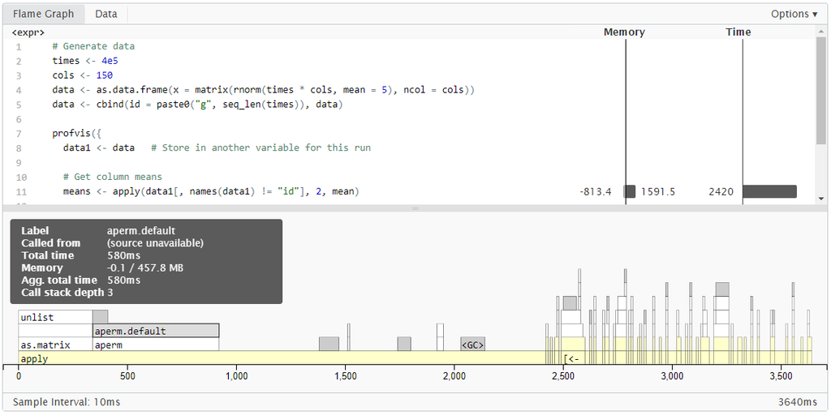

# Impact mémoire

- Dans **R** de base, avec la fonction `object.size()`. **Problème** : ne prend pas en compte toute la complexité potentielle des objects (environnements rattachés)
- Avec le package **pryr**
  - `object_size()`
  - `mem_used()` : mémoire utilisée, `mem_change(code)` : impact du code sur la mémoire

```r
# différence integer / numeric
v_int <- rep(1L, 1e8) ; v_num <- rep(1, 1e8)
object_size(v_int); object_size(v_num)
```

```
## 400.00 MB
```

```
## 800.00 MB
```

```r
mem_change(x <- 1:1e6) ; mem_change(rm(x))
```

```
## -5.38 kB
```

```
## 592 B
```

# Un petit mot sur le déboggage

- Pour voir simplement les informations : utilisation de *print()* dans la fonction
- Quand une erreur se produit, information du **traceback**
  - Disponible par défaut dans la console RStudio
  - via la fonction *traceback()* dans R
- Utilisation de la fonction *browser()* n’importe où dans le code : elle stoppe l’éxécution et lance un environnement dans lequel on peut accèder aux variables actuelles et continuer l’éxécution
- Insertion de points d’arrêt dans le code
- **RStudio** : menu *Debug*

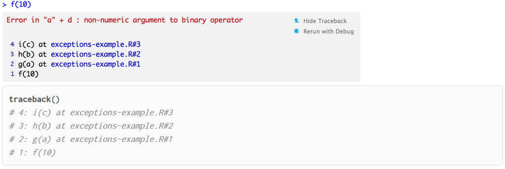

Plus d’informations ici : https://support.rstudio.com/hc/en-us/articles/205612627-Debugging-with-RStudio

# GESTION DES ERREURS ET DES MESSAGES

# Fonctions utiles

Quand **R** rencontre une erreur, il s’arrête net. Dans certains cas, on voudrait pouvoir continuer notre calcul. Trois fonctions sont diponibles dans R :

- *try()* : la plus simple pour contrôler l’apparition d’erreurs
- *tryCatch()* : la plus complète, avec la définition d’action en cas d’erreurs / warnings / messages
- *withCallingHandlers()* : une variante de tryCatch()

```r
test <- sapply(list(1:5,"a", 6:10), log)
#>Error in FUN(X[[2L]], ...) :
#  non-numeric argument to mathematical function
```

# try

`try(expr, silent = FALSE)`

- `silent` : affichage ou non d’erreur
- retourne un objet de **class** `try-error` incluant le message d’erreur

```r
test <- sapply(list(1:2,"a"), function(x) try(log(x), silent = TRUE));test
```

```
## [[1]]
## [1] 0.0000000 0.6931472
##
## [[2]]
## [1] "Error in log(x) : argument non numérique pour une fonction mathématique\n"
## attr(,"class")
## [1] "try-error"
## attr(,"condition")
## <simpleError in log(x): argument non numérique pour une fonction mathématique>
```

```r
# on récupére un object de class "try-error", avec le message d'erreur
class(test[[2]])
```

```
## [1] "try-error"
```

```r
test[[2]][1]
```

```
## [1] "Error in log(x) : argument non numérique pour une fonction mathématique\n"
```

# tryCatch

`tryCatch(expr, ..., finally)`

- `error = function(e)` : fonction à exécuter en cas d’erreur, `e` étant le message.
- idem avec `warning = function(e)` et `message = function(e)`

Si ces fonctions sont définies, elles seront donc évaluées le cas échéant **ET le calcul sera arrêté**

```r
test <- tryCatch(log("a"), error = function(e){
  print(e)
  return(0)
})
```

```
## <simpleError in log("a"): argument non numérique pour une fonction mathématique>
```

```r
test
```

```
## [1] 0
```

# withCallingHandlers

`withCallingHandlers(expr, ..., finally)`

- `error = function(e)` : fonction à exécuter en cas d’erreur, `e` étant le message
- idem avec `warning = function(e)` et `message = function(e)`

Si ces fonctions sont définies, elles seront donc évaluées le cas échéant **MAIS le calcul continuera**

```r
f <- function(){message("message") ; 0}
test <- withCallingHandlers(f(), message = function(e){e})
```

```
## message
```

```r
test
```

```
## [1] 0
```

```r
# tryCatch
test <- tryCatch(f(), message = function(e){e})
test
```

```
## <simpleMessage in message("message"): message
## >
```

# microbenchmark : temps de calculs

Pour monitorer le temps de calculs, la fonction `system.time()` peut-être utilisée, mais le package `microbenchmark` permet de monitorer avec plus de précision en répétant les appels.

```r
suppressWarnings(require(microbenchmark, quietly = TRUE))
x <- runif(1000)
microbenchmark(sqrt(x),x^{1/2},times=1000)
```

```
## Unit: microseconds
##           expr  min   lq     mean median    uq   max neval
##        sqrt(x)  5.2  8.2  15.3752   17.4  18.1 498.5  1000
##  x^{     1/2 } 44.3 63.3 113.6784  138.8 141.2 771.0  1000
```

# Profilage du code via Rprof (1/2)

Utiliser la fonction `Rprof` qui procède par échantillonnage : elle stoppe l’éxécution du code par intervalles (`interval`) et différencie le temps de calcul réalisé par chaque fonction (`self.time`) et le temps global (`total.time`).

```r
is.prime <- function(n){
  n == 2L || all(n %% 2L:ceiling(sqrt(n)) != 0)
}

all.prime <- function(n){
  v <- integer(0)
  for(i in 2:n){
    if(is.prime(i)){
      v <- c(v,i)
    }
  }
  v
}
```

```r
Rprof("Rprof.out", interval = 0.001)
prime.number <- all.prime(100000)
Rprof(NULL)
```

# Profilage du code via Rprof (2/2)

```r
summaryRprof("Rprof.out")
```

```
##             self.time self.pct total.time total.pct
## "is.prime"      0.071    47.97      0.109     73.65
## "%%"            0.033    22.30      0.033     22.30
## "c"             0.029    19.59      0.029     19.59
## "all.prime"     0.010     6.76      0.148    100.00
## "all"           0.005     3.38      0.005      3.38
```

```
##             total.time total.pct self.time self.pct
## "all.prime"      0.148    100.00     0.010     6.76
## "is.prime"       0.109     73.65     0.071    47.97
## "%%"             0.033     22.30     0.033    22.30
## "c"              0.029     19.59     0.029    19.59
## "all"            0.005      3.38     0.005     3.38
```

# Profilage avec profvis ou proftools

D’autres outils existent, avec notamment les packages **proftools** ou **profvis**

https://rstudio.github.io/profvis/

https://cran.r-project.org/web/packages/proftools/vignettes/proftools.pdf

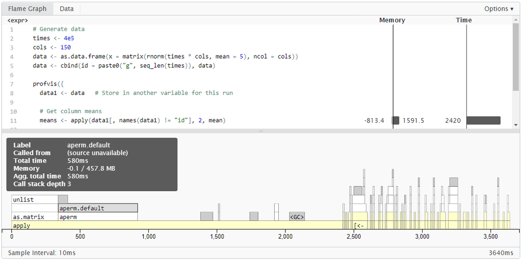

# Impact mémoire

- Dans **R** de base, avec la fonction `object.size()`. **Problème** : ne prend pas en compte toute la complexité potentielle des objects (environnements rattachés)
- Avec le package **pryr**
  - `object_size()`
  - `mem_used()` : mémoire utilisée, `mem_change(code)` : impact du code sur la mémoire

```r
# différence integer / numeric
v_int <- rep(1L, 1e8) ; v_num <- rep(1, 1e8)
object_size(v_int); object_size(v_num)
```

```
## 400.00 MB
```

```
## 800.00 MB
```

```r
mem_change(x <- 1:1e6) ; mem_change(rm(x))
```

```
## -7.59 kB
```

```
## 536 B
```

# Un petit mot sur le déboggage

- Pour voir simplement les informations : utilisation de *print()* dans la fonction
- Quand une erreur se produit, information du **traceback**
  - Disponible par défaut dans la console RStudio
  - via la fonction *traceback()* dans R
- Utilisation de la fonction *browser()* n’importe où dans le code : elle stoppe l’éxécution et lance un environnement dans lequel on peut accèder aux variables actuelles et continuer l’éxécution
- Insertion de points d’arrêt dans le code
- **RStudio** : menu *Debug*

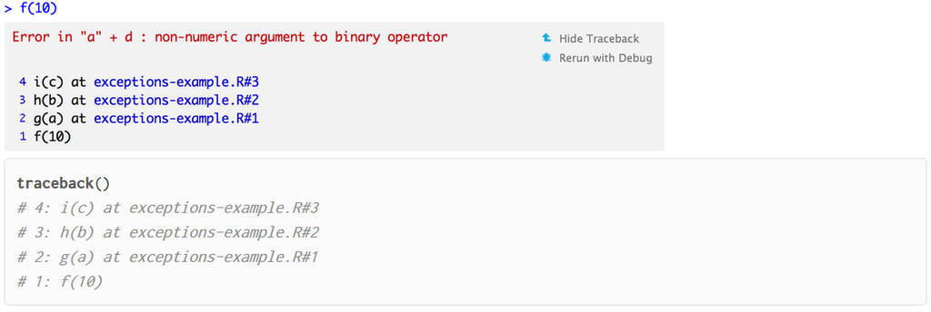

Plus d’informations ici : https://support.rstudio.com/hc/en-us/articles/205612627-Debugging-with-RStudio

**Aller plus loin…!**

- [The R Manuals](https://cran.r-project.org/manuals.html) : https://cran.r-project.org/manuals.html
- [R Contributed Documentation](https://cran.r-project.org/other-docs.html) : https://cran.r-project.org/other-docs.html
- [Advanced R by Hadley Wickham](http://adv-r.had.co.nz/) : http://adv-r.had.co.nz/
- [R packages by Hadley Wickham](http://r-pkgs.had.co.nz/) : http://r-pkgs.had.co.nz/
- [Tests using testthat](http://r-pkgs.had.co.nz/tests.html) : http://r-pkgs.had.co.nz/tests.html
- [Code coverage with covr](https://github.com/r-lib/covr) : https://github.com/r-lib/covr
- [How-to go parallel in R - basics + tips](http://gforge.se/2015/02/how-to-go-parallel-in-r-basics-tips/) : http://gforge.se/2015/02/how-to-go-parallel-in-r-basics-tips/
- [State of the Art in Parallel Computing withR](http://www.jstatsoft.org/v31/i01/paper) : http://www.jstatsoft.org/v31/i01/paper
- [R tutorial on the Apply family of functions](http://www.r-bloggers.com/r-tutorial-on-the-apply-family-of-functions/) : http://www.r-bloggers.com/r-tutorial-on-the-apply-family-of-functions/
- [A Tutorial on Loops in R - Usage and Alternatives](http://blog.datacamp.com/tutorial-on-loops-in-r/) : http://blog.datacamp.com/tutorial-on-loops-in-r/